# VR Behavioral Scoring

Leandro Ledesma

2024-02-10

### Universal block code settings

```r
knitr::opts_chunk$set(echo = TRUE)
knitr::opts_chunk$set(message = FALSE)
knitr::opts_chunk$set(comment = NULL)
```

### Load in the data manipulation packages first

```r
library(tidyverse)
library(ggplot2)
library(ggpubr)
library(readxl)
library(kableExtra)
```

### Load in the data

The Day.Labeling script (Step 1) cleaned the VR behavioral data and now it is ready for processing to be used for later analysis.

```r
# Set working directory
setwd("C:/Users/lledesma.TIMES/Documents/ONR/GnG_and_Nback_behavioral_data_preprocessing/Processed Data")

# Load in the data
GnG.original <- read.csv("GnG.day.type.added.csv")
Nback.original <- read.csv("Nback.day.type.added.csv")

# What is the dimensions
dim(GnG.original)
```

```
[1] 734310     42
```

```r
dim(Nback.original)
```

```
[1] 433540     42
```

```r
# Data cleaning- removing variable x
GnG.original <- GnG.original %>% select(-X)
Nback.original <- Nback.original %>% select(-X)
```

### Data reduction Go/No-Go Part 1 - Cleaning

We will be reducing the data by obtaining the scores of each person on variables of interest. This can be changed later to include more rows. For the Go/No-Go there are Day 0’s (practice days) and practice sessions that need to be removed. Then we can label the trials by Go or No-Go and finally use the group_by function to reduce the data to give us the mean scores for trial type for each ID on their respective testing day.

```r
# Remove Day 0 from our dataset or problematic day types (not noted in the visitor log)
GnG.removed.days <-  GnG.original %>%
  filter(!(Day.Type %in% c("Day 0", "Date not saved in the Visitor Log")))

# The dimensions of the new dataset
dim(GnG.removed.days)
```

```
[1] 662650     41
```

```r
# Remove practice trials
GnG.practice.blocks <- c(paste("G",1:5,"0",sep=""))
GnG.removed.practice.blocks <- GnG.removed.days %>%
  filter(!(BlockID %in% GnG.practice.blocks))

# The dimensions of the new dataset
dim(GnG.removed.practice.blocks)
```

```
[1] 604970     41
```

```r
# Extra check
GnG.removed.practice.blocks %>%
  select(BlockName) %>%
  table() %>%
  prop.table() %>%
  names()
```

```
 [1] "Color  Shape and Reverse Arrow"
 [2] "Color  Shape and Reverse Arrow  Day 0"
 [3] "Colors  Shape  and Arrow"
 [4] "Colors  Shape  and Arrow  Day 0"
 [5] "Colors and Shape"
 [6] "Colors and Shape  Day 0"
 [7] "Colors and Shape with fixed ISI"
 [8] "Colors and Shape with fixed ISI  Day 0"
 [9] "Saber Color Matching"
[10] "Saber Color Matching  Day 0"
```

```r
# Remove the Day 0's still present in the data
remaining.practice.trials <-c("Colors  Shape  and Arrow  Day 0",
                              "Color  Shape and Reverse Arrow  Day 0",
                              "Colors and Shape  Day 0",
                              "Colors and Shape with fixed ISI  Day 0",
                              "Saber Color Matching  Day 0")

GnG.removed.practice.blocks <- GnG.removed.practice.blocks %>%
  filter(!(BlockName %in% remaining.practice.trials))

# Extra check again
GnG.removed.practice.blocks %>%
  select(BlockName) %>%
  table() %>%
  prop.table() %>%
  names()
```

```
[1] "Color  Shape and Reverse Arrow"  "Colors  Shape  and Arrow"
[3] "Colors and Shape"                "Colors and Shape with fixed ISI"
[5] "Saber Color Matching"
```

```r
# Add Go and No-Go Labels (This was tested and it came out correct 20/80)
go.trials <- c("G1", "G5", "G8", "G12")
GnG.trial.type <- GnG.removed.practice.blocks %>%
  mutate(Trial.Type = ifelse(ItemID %in% go.trials, "Go", "No-Go"))
```

### Data reduction Go/No-Go Part 2 - Actual data reduction

```r
# Reduce the dimensions even more by grouping and obtaining performance score for each block type
# Every subject should have 30 rows: 2 (trial types) x 5 (BlockName) x 3 (Days) = 30
GnG.grouped.Trial.Type <- GnG.trial.type %>%
  group_by(UserID, BlockName, Trial.Type, Day.Type) %>%
  mutate(trial.mean.correct = round(mean(Correct),2),
         mean.score = round(mean(ItemScore)),
         trial.num = length(Correct)) %>%
  ungroup() %>%
  select(UserID, BlockName, Trial.Type, Day.Type, mean.score, trial.mean.correct, trial.num) %>%
  unique()


# Create another data frame that reduced dimensions but only for correct reaction times of Go-Trials
GnG.grouped.Reaction.Time <- GnG.trial.type %>%
  group_by(UserID,Trial.Type, Correct, BlockName, Day.Type) %>%
  summarize(mean.RT = mean(TimeToImpact))
```

### Data reduction Go/No-Go Part 3 - Quality Control

[1] “This section is the quality control for: ‘GnG.grouped.Trial.Type’” [1] “This dataset contains 211 unique IDs.” [1] “The following table shows the frequency of each GnG Condition for all subjects for each trial type:” , , = Go

```
                              Day 1 Day 2 Day 3
```

Color Shape and Reverse Arrow 211 197 167 Colors Shape and Arrow 211 197 167 Colors and Shape 211 197 167 Colors and Shape with fixed ISI 211 197 167 Saber Color Matching 211 197 167

, , = No-Go

```
                              Day 1 Day 2 Day 3
```

Color Shape and Reverse Arrow 211 197 167 Colors Shape and Arrow 211 197 167 Colors and Shape 211 197 167 Colors and Shape with fixed ISI 211 197 167 Saber Color Matching 211 197 167

[1] “Let’s view the distribution of scores for Go and No-Go trials, averaged to no include days”

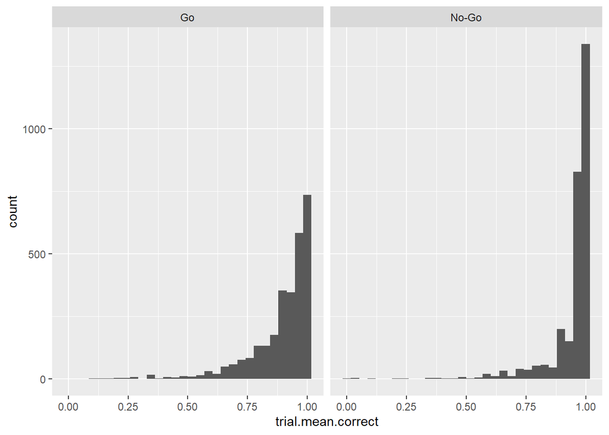

[1] “This section is the quality control for: ‘GnG.grouped.Reaction.Time’” [1] “This dataset contains 211 unique IDs.” [1] “Quality check 1: Are there -1 for reaction times for correct go trials?” Min. 1st Qu. Median Mean 3rd Qu. Max. 190.8 631.7 850.5 785.2 918.8 1162.3 [1] “What is the proportion of Go/No-Go trials in the original dataset?” Proportion Go 0.8 No-Go 0.2

### Data reduction Nback

Same procedure as above. We will be removing practice days and practice sessions then labeling the trials by either target or distractor Afterwards we will obtain the mean scores of performance for each trial type for all participants on their respective testing days.

This dataset does not have an item ID to determine between target stimuli and non-target stimuli (distractor). Thus we devised a way to measure this using code. Our N-back is a 2-back, meaning that the participant must hit a shape that matches two shapes ago. The CSV files recorded indicate the order of shapes presented in row order. Thus the first item presented was recorded in row one and the second item was recorded in row two and so on until the completion of the task. Knowing this, we can copy and paste the the order of items and shift it two rows down. Then, any rows that match between these two variables (original and the shifted two down) will indicate a target trial- below will be a demonstration.

```r
# Remove Day 0 from our dataset or problematic day types (not noted in the visitor log)
Nback.removed.days <- Nback.original %>%
    filter(!(Day.Type %in% c("Day 0", "Date not saved in the Visitor Log")))

# The dimensions of our new dataset
dim(Nback.removed.days)
```

```
[1] 385740     41
```

```r
# Keep all non practice blocks (there are not practice trials but blocks)
non.practice.blocks <- c("N1","N2","N3","N4")
Nback.kept.non.practice.blocks <- Nback.removed.days %>%
  filter(BlockID %in% non.practice.blocks)

# The dimensions of our new dataset
dim(Nback.kept.non.practice.blocks)
```

```
[1] 363020     41
```

```r
# Extra check
Nback.kept.non.practice.blocks %>%
  select(BlockName) %>%
  table() %>%
  prop.table() %>%
  names()
```

```
[1] "2-Back AR w D"   "2-Back AR w ND"  "2-Back RAR w D"  "2-Back RAR w ND"
```

```r
##################################################################################################
# Add target and distracter labels to all Nback sessions
# Create an empty list
all.Nback.sessions <- list()

# Create a 'file.name' for file extraction
Nback.file.names <- Nback.kept.non.practice.blocks %>% select(UserID, Day.Type) %>% group_by(UserID, Day.Type) %>% unique()


# Run the loop
for(ii in 1:nrow(Nback.file.names)) {

  # Extract the ID in the list
  current.ID <- Nback.file.names$UserID[ii]

  # Extract the  Day Type in the list
  current.Day.Type <- Nback.file.names$Day.Type[ii]

  # Use ID and Day Type to subset one CSV file from the Nback
  current.Nback <- Nback.kept.non.practice.blocks %>%
    filter(UserID == current.ID & Day.Type == current.Day.Type)

  # Split the Figure variable to obtain the sequence of shown stimuli and save that as a separate data frame
  split.Figure.df <- str_split(current.Nback$Figure, pattern = "_") %>%
    do.call(rbind,.) %>%
    data.frame() %>%
    select(-X3)

  # Give them names associated with what is being measure
  names(split.Figure.df) <- c("Shape", "Sequence")

  # Introduce them into the main Nback dataframe
  current.Nback2 <- cbind(current.Nback, split.Figure.df)

  # Add the second variable that duplicates ItemID and shifts it down two rows
  current.Nback2$ItemID2 <- c("-", "-", current.Nback2$ItemID[1:(length(current.Nback2$ItemID)-2)])

  # Use the second variable to identify target trials by marking matching rows as 'Target
  current.Nback2 <- current.Nback2 %>%
    mutate(Trial.Type = case_when(

      ItemID == ItemID2 & Sequence %in% c(2:19) ~ "Target",
      ItemID != ItemID2 & Sequence %in% c(2:19) ~ "Non-Target",
      TRUE ~ "First/Second Trial"

    )) %>%
    select(UserID, BlockID, ItemID, ItemID2, Trial.Type, everything())

  # Save this manipulation into the list
  all.Nback.sessions[[ii]] <- current.Nback2
}

# Save the list with the transformation back as a dataframe
Nback.trial.type <- all.Nback.sessions%>%
  do.call(rbind,.) %>%
  data.frame()



# Reduce the dimensions even more by grouping and obtaining performance score for each block type
Nback.grouped.Trial.Type <- Nback.trial.type %>%
  group_by(UserID, BlockName, Trial.Type, Day.Type) %>%
  summarize(trial.mean.correct = round(mean(Correct),2),
            mean.score = round(mean(ItemScore)),
            trial.num = length(Correct))

# Create another data frame that reduced dimensions but only for correct reaction times of Nback
Nback.grouped.Reaction.Time <- Nback.trial.type %>%
  group_by(UserID,Trial.Type, Correct, BlockName, Day.Type) %>%
  summarize(mean.RT = mean(TimeToImpact))

### Additionally- we are going to save this data frame to the Nback as a reaction to a target trial being correct
# This means that it ignores trials being wrong by not hitting with the arrows.
Nback.grouped.Reaction.Target <- Nback.trial.type %>%
  group_by(UserID, BlockName, Trial.Type, Day.Type) %>%
  mutate(target.mean.reacted = round(mean(Reacted),2),
         trial.num = length(Reacted)) %>%
  ungroup() %>%
  select(UserID, BlockName, Trial.Type, Day.Type, target.mean.reacted, trial.num) %>%
  unique()
```

### Nback quality control (to send to Mark)

Identifying that there are 20% Target trials as expected. Also identifying that there are no trials where a target that is correct has a -1 reaction time.

```r
### Quality control, get the frequency of each
data.frame(Frequency = cbind(table(Nback.trial.type$Trial.Type))) %>%
  mutate(Total = sum(Frequency),
         Percentage = Frequency/Total * 100)
```

```
                   Frequency  Total Percentage
First/Second Trial     36302 363020         10
Non-Target            254114 363020         70
Target                 72604 363020         20
```

```r
# Checking a -1 value for reaction time for correct target trials
Nback.trial.type %>%
  filter(Trial.Type == "Target" & Correct == 1) %>%
  select(TimeToImpact) %>%
  unlist() %>%
  summary()
```

```
   Min. 1st Qu.  Median    Mean 3rd Qu.    Max.
  130.7   834.6   896.8   884.9   936.4  1103.6
```

### Reduce data dimensionality for vigilance decrement

```r
# Reduce the data dimensionality for the GnG
# We can identify the order by taking advantage of the unique function
# unique tells us two things, the first is all of the unique values in a variable
# and secondly the order of those unique values in the dataset- we can use this to our advantage

unique.IDs <- unique(GnG.trial.type$UserID)
unique.Days <- unique(GnG.trial.type$Day.Type)

all.ordered.list <- list()

for (ii in 1:length(unique.IDs)) {

  # Extract the first ID
  current.ID <- unique.IDs[ii]
  current.data <- GnG.trial.type %>%
    filter(UserID == current.ID)

  all.days.list <- list()
  for (iii in 1:3) {

    # Extract by day
    current.day <- unique.Days[iii]
    current.data.day <- current.data %>%
      filter(Day.Type == current.day)

    # Extract the current order of blocks for this day
    block.order <- unique(current.data.day$BlockName)

    # Introduce a new variable that adds the order of each block displayed
    current.data.day <- current.data.day %>%
      mutate(Order = case_when(
        BlockName == block.order[1] ~ 1,
        BlockName == block.order[2] ~ 2,
        BlockName == block.order[3] ~ 3,
        BlockName == block.order[4] ~ 4,
        BlockName == block.order[5] ~ 5,
        TRUE ~ 0
      ))

    all.days.list[[iii]] <- current.data.day
  }

  all.ordered.list[[ii]] <- do.call(rbind,all.days.list)
}

# Save it as one large dataset
GnG.ordered <- do.call(rbind, all.ordered.list)


# Data dimensionality
GnG.ordered.reduced <- GnG.ordered %>%
  mutate(BlockName_and_order = paste(BlockName, Order)) %>%
  group_by(UserID, BlockName_and_order, Trial.Type, Day.Type) %>%
  summarize(trial.mean.order.correct = round(mean(Correct),2),
            mean.score = round(mean(ItemScore)),
            trial.num = length(Correct)) %>%
  arrange(Day.Type)

# Extract order and blockname from the variable that contains both
GnG.ordered.reduced$Order <-  as.numeric(gsub("\\D", "", GnG.ordered.reduced$BlockName_and_order))
GnG.ordered.reduced$BlockName <- gsub("[^a-zA-Z]", " ", GnG.ordered.reduced$BlockName_and_order)

# Remove the variable with information on both
GnG.ordered.reduced <- GnG.ordered.reduced %>%
  ungroup() %>%
  select(-BlockName_and_order)


head(table(GnG.ordered$UserID, GnG.ordered$Order))
```

```
      1   2   3   4   5
  1 630 630 630 630 630
  2 630 630 630 630 630
  3 630 630 630 630 630
  4 630 630 630 630 630
  6 210 210 210 210 210
  9 630 630 630 630 630
```

### Save the data (locally)

```r
# Set the save directory
setwd("C:/Users/lledesma.TIMES/Documents/ONR/GnG_and_Nback_behavioral_data_preprocessing/Processed Data")

# Save the data
write_csv(x = GnG.grouped.Trial.Type,
          file = "GnG.trial.type.csv")

write_csv(x = GnG.grouped.Reaction.Time,
          file = "GnG.reaction.time.csv")

write_csv(x = Nback.grouped.Trial.Type,
          file = "Nback.trial.type.csv")

write_csv(x = Nback.grouped.Reaction.Time,
          file = "Nback.reaction.time.csv")

write_csv(x = Nback.grouped.Reaction.Target,
          file = "Nback.target.reacted.csv")

write_csv(x = GnG.ordered.reduced,
          file = "GnG.conditions.ordered.csv")
```

### Save the data to the server

```r
# Set another save directory
setwd("M:/Qualtrics_Data/Processed data/VR Performance")

# Save the data
write_csv(x = GnG.grouped.Trial.Type,
          file = "GnG.trial.type.csv")

write_csv(x = GnG.grouped.Reaction.Time,
          file = "GnG.reaction.time.csv")

write_csv(x = Nback.grouped.Trial.Type,
          file = "Nback.trial.type.csv")

write_csv(x = Nback.grouped.Reaction.Time,
          file = "Nback.reaction.time.csv")

write_csv(x = Nback.grouped.Reaction.Target,
          file = "Nback.target.reacted.csv")

write_csv(x = GnG.ordered.reduced,
          file = "GnG.conditions.ordered.csv")
```

[output not shown]